# PigWeb: infrared

Author

Liza Moscoviche & Anja Eggert

Published

January 27, 2025

# Libraries

```r
library(kableExtra)
library(tidyverse)
library(rstatix)
library(lmerTest)
library(car)
library(performance)
library(emmeans)
```

# Scripts, etc.

```r
contr = lmerControl(optimizer   = "bobyqa",
                    optCtrl     = list(maxfun = 10000000),
                    calc.derivs = FALSE)
```

```r
my_theme = theme_classic() +
  theme(text = element_text(family = "sans"),
        plot.title   = element_text(face = "plain", size = 16),
        axis.title   = element_text(face = "bold", size = 16),
        axis.text    = element_text(size = 14, angle = 0, vjust = 0.5),
        legend.title = element_text(face = "bold", size = 16),
        legend.text  = element_text(face = "plain", size = 16),
        strip.text   = element_text(size = 16),
        legend.position = "top",
        panel.grid.major = element_blank(),
        panel.grid.minor = element_blank())
```

```r
set.seed(1989)
```

# Data

Analysis of infrared data from 2 institutes, AU and IRTA. No data available from other institutes.

## Read data

```r
dat <- read_csv("./data/PigWeb-physiology.csv",
                show_col_types = FALSE)
```

## Process data

```r
dat <- dat |>
  mutate(across(where(is.character), as.factor)) |>
  mutate(date           = dmy(date),
         date.f         = as.factor(date),
         institute      = fct_relevel(institute, "AU", "INRAE", "IRTA", "WUR"),
         institute      = relevel(institute, ref = "AU"),
         sample         = relevel(sample,    ref = "pre"),
         context        = relevel(context,   ref = "negative"),
         time_collect   = hour(time) + minute(time)/60,
         time_collect.z    = as.vector(scale(time_collect)),
         weight_start_kg.z = as.vector(scale(weight_start_kg)))
```

# Descriptive statistics across context

## Data from AU

```r
dat |>
  group_by(context) |>
  rstatix::get_summary_stats(eye_IRT_max,
                             show = c("median","q1", "q3")) |>
  ungroup() |>
  arrange(variable) |>
  mutate(across(c(median, q1, q3), ~ round(., 1))) |>
  kable(caption = "Text for Tab. 9") |>
  kable_styling(bootstrap_options = c("striped", "hover"), font_size = 12) |>
  scroll_box()
```

| context | variable | n | median | q1 | q3 |
| --- | --- | --- | --- | --- | --- |
| negative | eye_IRT_max | 40 | 36.9 | 36.6 | 37.5 |
| positive | eye_IRT_max | 40 | 37.3 | 36.9 | 38.2 |

```r
dat |>
  group_by(posture_at_sampling) |>
  rstatix::get_summary_stats(eye_IRT_max,
                             show = c("median","q1", "q3")) |>
  ungroup() |>
  arrange(variable) |>
  mutate(across(c(median, q1, q3), ~ round(., 1))) |>
  kable(caption = "Text for Tab. 9") |>
  kable_styling(bootstrap_options = c("striped", "hover"), font_size = 12) |>
  scroll_box()
```

| posture_at_sampling | variable | n | median | q1 | q3 |
| --- | --- | --- | --- | --- | --- |
| lying | eye_IRT_max | 25 | 38 | 37.2 | 38.5 |
| standing | eye_IRT_max | 55 | 37 | 36.7 | 37.4 |

## Data from IRTA

```r
dat |>
  group_by(sample) |>
  rstatix::get_summary_stats(ear_IRT_max,
                             show = c("median","q1", "q3")) |>
  ungroup() |>
  arrange(variable) |>
  mutate(across(c(median, q1, q3), ~ round(., 1))) |>
  kable(caption = "Text for Tab. 10") |>
  kable_styling(bootstrap_options = c("striped", "hover"), font_size = 12) |>
  scroll_box()
```

| sample | variable | n | median | q1 | q3 |
| --- | --- | --- | --- | --- | --- |
| pre | ear_IRT_max | 22 | 35.1 | 33.7 | 36.7 |
| post | ear_IRT_max | 22 | 36.9 | 36.0 | 38.1 |

# Model eye temperature (AU data)

Full model:

```r
mod.AU <- lmerTest::lmer(eye_IRT_max ~
                           sample * context   +
                           posture_at_sampling +
                           weight_start_kg.z +
                           (1|pig_group_unique),
                         data    = dat,
                         REML    = FALSE,
                         control = contr)
```

Reduced model, without interactions and without `sample` and `context`:

```r
mod.AU.red <- lmerTest::lmer(eye_IRT_max ~
                               posture_at_sampling +
                               weight_start_kg.z +
                               (1|pig_group_unique),
                             data    = dat,
                             REML    = FALSE,
                             control = contr)
```

Comparison of reduced and full model:

```r
anova(mod.AU.red, mod.AU, test = "Chisq")
```

```
Data: dat
Models:
mod.AU.red: eye_IRT_max ~ posture_at_sampling + weight_start_kg.z + (1 | pig_group_unique)
mod.AU: eye_IRT_max ~ sample * context + posture_at_sampling + weight_start_kg.z + (1 | pig_group_unique)
           npar    AIC    BIC   logLik deviance  Chisq Df Pr(>Chisq)
mod.AU.red    5 212.20 224.11 -101.100   202.20
mod.AU        8 208.38 227.44  -96.192   192.38 9.8158  3     0.0202 *
---
Signif. codes:  0 '***' 0.001 '**' 0.01 '*' 0.05 '.' 0.1 ' ' 1
```

But final model without interaction term, as it is not significant:

```r
mod.AU <- lmerTest::lmer(eye_IRT_max ~
                           sample +
                           context   +
                           posture_at_sampling +
                           weight_start_kg.z +
                           (1|pig_group_unique),
                         data    = dat,
                         REML    = FALSE,
                         control = contr)
```

## Final model

Get effect estimates and standard errors of the model fitted with ML (`REML = FALSE`):

```r
round(summary(mod.AU)$coefficients, 2)
```

```
                            Estimate Std. Error    df t value Pr(>|t|)
(Intercept)                    38.21       0.85 73.82   44.81     0.00
samplepost                      0.35       0.18 73.05    1.90     0.06
contextpositive                 0.46       0.18 72.77    2.60     0.01
posture_at_samplingstanding    -0.63       0.21 78.48   -3.03     0.00
weight_start_kg.z              -0.35       0.36 68.16   -0.98     0.33
```

Get *p* values of fixed effects and interactions of the model fitted with REML (`REML = TRUE`). Using `drop1()`, for factors that are part of interactions, the main effect cannot be tested. In this case `car::Anova` can be used:

```r
round(drop1(mod.AU |> update(REML = TRUE),
            test = "Chisq"), 3)
```

```
Single term deletions using Satterthwaite's method:

Model:
eye_IRT_max ~ sample + context + posture_at_sampling + weight_start_kg.z + (1 | pig_group_unique)
                    Sum Sq Mean Sq NumDF  DenDF F value Pr(>F)
sample               2.283   2.283     1 69.397   3.400  0.069 .
context              4.315   4.315     1 69.153   6.425  0.014 *
posture_at_sampling  5.928   5.928     1 73.892   8.827  0.004 **
weight_start_kg.z    0.561   0.561     1 64.537   0.835  0.364
---
Signif. codes:  0 '***' 0.001 '**' 0.01 '*' 0.05 '.' 0.1 ' ' 1
```

```r
car::Anova(mod.AU |> update(REML = TRUE),
           test.statistic = "Chisq",
           type = 3) # as with interaction, otherwise set type = 2
```

```
Analysis of Deviance Table (Type III Wald chisquare tests)

Response: eye_IRT_max
                        Chisq Df Pr(>Chisq)
(Intercept)         1860.3994  1  < 2.2e-16 ***
sample                 3.3999  1   0.065199 .
context                6.4247  1   0.011254 *
posture_at_sampling    8.8271  1   0.002968 **
weight_start_kg.z      0.8349  1   0.360873
---
Signif. codes:  0 '***' 0.001 '**' 0.01 '*' 0.05 '.' 0.1 ' ' 1
```

```r
car::Anova(mod.AU |> update(REML = TRUE),
           test.statistic = "F",
           type = 3) # as with interaction, otherwise set type = 2
```

```
Analysis of Deviance Table (Type III Wald F tests with Kenward-Roger df)

Response: eye_IRT_max
                            F Df Df.res    Pr(>F)
(Intercept)         1708.1533  1 68.197 < 2.2e-16 ***
sample                 3.3959  1 68.471  0.069687 .
context                6.4246  1 68.191  0.013555 *
posture_at_sampling    8.5749  1 73.695  0.004532 **
weight_start_kg.z      0.7495  1 62.947  0.389909
---
Signif. codes:  0 '***' 0.001 '**' 0.01 '*' 0.05 '.' 0.1 ' ' 1
```

## Model diagnostics

Combined diagnostics:

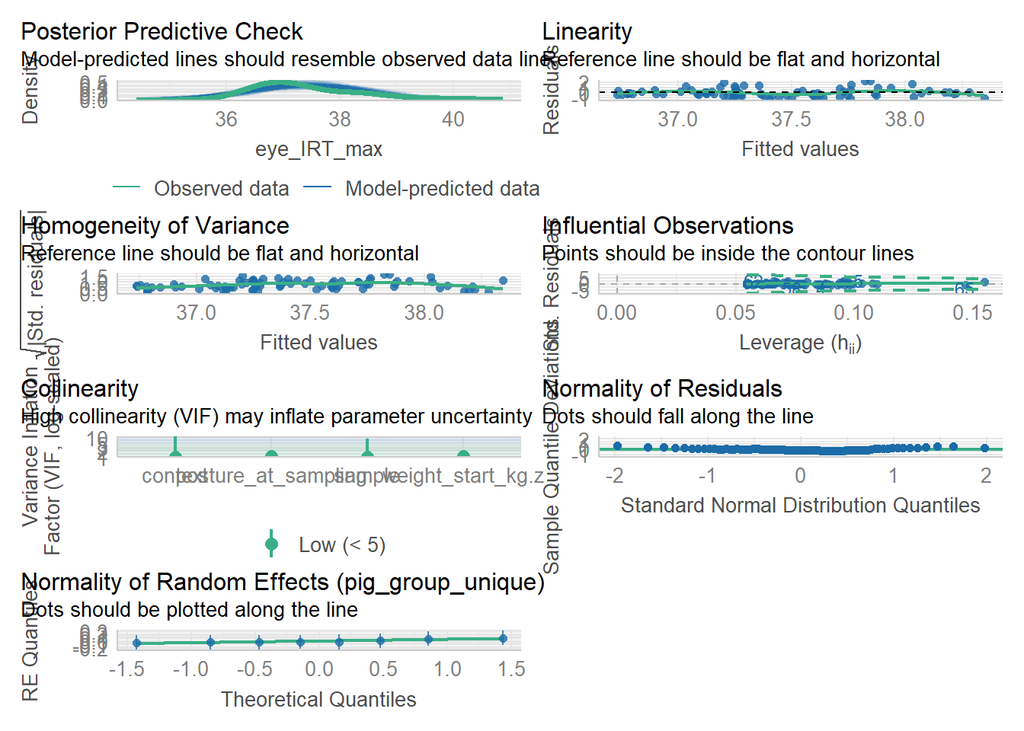

```r
performance::check_model(mod.AU)
```

Collinearity:

```r
xx=lm(eye_IRT_max ~
        sample +
        context +
        posture_at_sampling +
        weight_start_kg.z,
      data = dat)
car::vif(xx)
```

```
             sample             context posture_at_sampling   weight_start_kg.z
           1.041118            1.000839            1.153809            1.111853
```

# Model ear temperature (IRTA data)

Model with one interaction of fixed effects and random intercepts but constant slope.

Full model:

```r
mod.IRTA <- lmerTest::lmer(ear_IRT_max ~
                             sample * context   +
                             weight_start_kg.z +
                             (1|pig_id_unique),
                           data    = dat,
                           REML    = FALSE,
                           control = contr)
```

Reduced model, without interactions and without `sample` and `context`:

```r
mod.IRTA.red <- lmerTest::lmer(ear_IRT_max ~
                             weight_start_kg.z +
                             (1|pig_id_unique),
                           data    = dat,
                           REML    = FALSE,
                           control = contr)
```

Comparison of reduced and full model:

```r
anova(mod.IRTA.red, mod.IRTA, test = "Chisq")
```

```
Data: dat
Models:
mod.IRTA.red: ear_IRT_max ~ weight_start_kg.z + (1 | pig_id_unique)
mod.IRTA: ear_IRT_max ~ sample * context + weight_start_kg.z + (1 | pig_id_unique)
             npar    AIC    BIC  logLik deviance  Chisq Df Pr(>Chisq)
mod.IRTA.red    4 193.62 200.76 -92.811   185.62
mod.IRTA        7 190.99 203.48 -88.497   176.99 8.6273  3    0.03468 *
---
Signif. codes:  0 '***' 0.001 '**' 0.01 '*' 0.05 '.' 0.1 ' ' 1
```

But final model without interaction term, as it is not significant:

```r
mod.IRTA <- lmerTest::lmer(ear_IRT_max ~
                             sample +
                             context   +
                             weight_start_kg.z +
                             (1|pig_id_unique),
                           data    = dat,
                           REML    = FALSE,
                           control = contr)
```

## Final model

Get effect estimates and standard errors of the model fitted with ML (`REML = FALSE`):

```r
round(summary(mod.IRTA)$coefficients, 2)
```

```
                  Estimate Std. Error    df t value Pr(>|t|)
(Intercept)          35.52       0.55 32.33   64.13     0.00
samplepost            1.52       0.49 22.00    3.08     0.01
contextpositive      -0.32       0.65 22.00   -0.49     0.63
weight_start_kg.z    -0.26       2.83 22.00   -0.09     0.93
```

Get *p* values of fixed effects and interactions of the model fitted with REML (`REML = TRUE`). Using `drop1()`, for factors that are part of interactions, the main effect cannot be tested. In this case `car::Anova` can be used:

```r
round(drop1(mod.IRTA |> update(REML = TRUE),
            test = "Chisq"), 3)
```

```
Single term deletions using Satterthwaite's method:

Model:
ear_IRT_max ~ sample + context + weight_start_kg.z + (1 | pig_id_unique)
                  Sum Sq Mean Sq NumDF DenDF F value Pr(>F)
sample            25.506  25.506     1    21   9.034  0.007 **
context            0.587   0.587     1    19   0.208  0.654
weight_start_kg.z  0.021   0.021     1    19   0.007  0.932
---
Signif. codes:  0 '***' 0.001 '**' 0.01 '*' 0.05 '.' 0.1 ' ' 1
```

```r
car::Anova(mod.IRTA |> update(REML = TRUE),
           test.statistic = "Chisq",
           type = 3) # as with interaction, otherwise set type = 2
```

```
Analysis of Deviance Table (Type III Wald chisquare tests)

Response: ear_IRT_max
                      Chisq Df Pr(>Chisq)
(Intercept)       3620.4807  1    < 2e-16 ***
sample               9.0340  1    0.00265 **
context              0.2079  1    0.64843
weight_start_kg.z    0.0074  1    0.93132
---
Signif. codes:  0 '***' 0.001 '**' 0.01 '*' 0.05 '.' 0.1 ' ' 1
```

```r
car::Anova(mod.IRTA |> update(REML = TRUE),
           test.statistic = "F",
           type = 3) # as with interaction, otherwise set type = 2
```

```
Analysis of Deviance Table (Type III Wald F tests with Kenward-Roger df)

Response: ear_IRT_max
                          F Df Df.res    Pr(>F)
(Intercept)       3620.4807  1 27.285 < 2.2e-16 ***
sample               9.0340  1 21.000  0.006734 **
context              0.2079  1 19.000  0.653598
weight_start_kg.z    0.0074  1 19.000  0.932223
---
Signif. codes:  0 '***' 0.001 '**' 0.01 '*' 0.05 '.' 0.1 ' ' 1
```

## Model diagnostics

Combined diagnostics:

[figure not shown]

```r
performance::check_model(mod.AU)
```

Collinearity:

```r
xx=lm(eye_IRT_max ~
        sample +
        context +
        posture_at_sampling +
        weight_start_kg.z,
      data = dat)
car::vif(xx)
```

[output not shown]

# Citing R

“All analyses were performed using R Statistical Software (version 4.4.2; R Core Team 2024)”.

Reference: R Core Team (2024). R: A language and environment for statistical computing. R Foundation for Statistical Computing, Vienna, Austria. URL https://www.R-project.org/.

```r
citation()
```

```
  R Core Team (2024). _R: A Language and Environment for Statistical
  Computing_. R Foundation for Statistical Computing, Vienna, Austria.
  <https://www.R-project.org/>.

Ein BibTeX-Eintrag für LaTeX-Benutzer ist

  @Manual{,
    title = {R: A Language and Environment for Statistical Computing},
    author = {{R Core Team}},
    organization = {R Foundation for Statistical Computing},
    address = {Vienna, Austria},
    year = {2024},
    url = {https://www.R-project.org/},
  }

We have invested a lot of time and effort in creating R, please cite it
when using it for data analysis. See also 'citation("pkgname")' for
citing R packages.
```

```r
version$version.string
```

```
[1] "R version 4.4.2 (2024-10-31 ucrt)"
```

```r
citation("kableExtra")
```

```
Um Paket 'kableExtra' in Publikationen zu zitieren, nutzen Sie bitte:

  Zhu H (2024). _kableExtra: Construct Complex Table with 'kable' and
  Pipe Syntax_. R package version 1.4.0,
  <https://CRAN.R-project.org/package=kableExtra>.

Ein BibTeX-Eintrag für LaTeX-Benutzer ist

  @Manual{,
    title = {kableExtra: Construct Complex Table with 'kable' and Pipe Syntax},
    author = {Hao Zhu},
    year = {2024},
    note = {R package version 1.4.0},
    url = {https://CRAN.R-project.org/package=kableExtra},
  }
```

```r
citation("tidyverse")
```

```
Um Paket 'tidyverse' in Publikationen zu zitieren, nutzen Sie bitte:

  Wickham H, Averick M, Bryan J, Chang W, McGowan LD, François R,
  Grolemund G, Hayes A, Henry L, Hester J, Kuhn M, Pedersen TL, Miller
  E, Bache SM, Müller K, Ooms J, Robinson D, Seidel DP, Spinu V,
  Takahashi K, Vaughan D, Wilke C, Woo K, Yutani H (2019). "Welcome to
  the tidyverse." _Journal of Open Source Software_, *4*(43), 1686.
  doi:10.21105/joss.01686 <https://doi.org/10.21105/joss.01686>.

Ein BibTeX-Eintrag für LaTeX-Benutzer ist

  @Article{,
    title = {Welcome to the {tidyverse}},
    author = {Hadley Wickham and Mara Averick and Jennifer Bryan and Winston Chang and Lucy D'Agostino McGowan and Romain François and Garrett Grolemund and Alex Hayes and Lionel Henry and Jim Hester and Max Kuhn and Thomas Lin Pedersen and Evan Miller and Stephan Milton Bache and Kirill Müller and …
    year = {2019},
    journal = {Journal of Open Source Software},
    volume = {4},
    number = {43},
    pages = {1686},
    doi = {10.21105/joss.01686},
  }
```

```r
citation("rstatix")
```

```
Um Paket 'rstatix' in Publikationen zu zitieren, nutzen Sie bitte:

  Kassambara A (2023). _rstatix: Pipe-Friendly Framework for Basic
  Statistical Tests_. R package version 0.7.2,
  <https://CRAN.R-project.org/package=rstatix>.

Ein BibTeX-Eintrag für LaTeX-Benutzer ist

  @Manual{,
    title = {rstatix: Pipe-Friendly Framework for Basic Statistical Tests},
    author = {Alboukadel Kassambara},
    year = {2023},
    note = {R package version 0.7.2},
    url = {https://CRAN.R-project.org/package=rstatix},
  }
```

```r
citation("lmerTest")
```

```
  Kuznetsova A, Brockhoff PB, Christensen RHB (2017). "lmerTest
  Package: Tests in Linear Mixed Effects Models." _Journal of
  Statistical Software_, *82*(13), 1-26. doi:10.18637/jss.v082.i13
  <https://doi.org/10.18637/jss.v082.i13>.

Ein BibTeX-Eintrag für LaTeX-Benutzer ist

  @Article{,
    title = {{lmerTest} Package: Tests in Linear Mixed Effects Models},
    author = {Alexandra Kuznetsova and Per B. Brockhoff and Rune H. B. Christensen},
    journal = {Journal of Statistical Software},
    year = {2017},
    volume = {82},
    number = {13},
    pages = {1--26},
    doi = {10.18637/jss.v082.i13},
  }
```

```r
citation("car")
```

```
  Fox J, Weisberg S (2019). _An R Companion to Applied Regression_,
  Third edition. Sage, Thousand Oaks CA.
  <https://www.john-fox.ca/Companion/>.

Ein BibTeX-Eintrag für LaTeX-Benutzer ist

  @Book{,
    title = {An {R} Companion to Applied Regression},
    edition = {Third},
    author = {John Fox and Sanford Weisberg},
    year = {2019},
    publisher = {Sage},
    address = {Thousand Oaks {CA}},
    url = {https://www.john-fox.ca/Companion/},
  }
```

```r
citation("performance")
```

```
Um Paket 'performance' in Publikationen zu zitieren, nutzen Sie bitte:

  Lüdecke et al., (2021). performance: An R Package for Assessment,
  Comparison and Testing of Statistical Models. Journal of Open Source
  Software, 6(60), 3139. https://doi.org/10.21105/joss.03139

Ein BibTeX-Eintrag für LaTeX-Benutzer ist

  @Article{,
    title = {{performance}: An {R} Package for Assessment, Comparison and Testing of Statistical Models},
    author = {Daniel Lüdecke and Mattan S. Ben-Shachar and Indrajeet Patil and Philip Waggoner and Dominique Makowski},
    year = {2021},
    journal = {Journal of Open Source Software},
    volume = {6},
    number = {60},
    pages = {3139},
    doi = {10.21105/joss.03139},
  }
```

```r
citation("emmeans")
```

```
Um Paket 'emmeans' in Publikationen zu zitieren, nutzen Sie bitte:

  Lenth R (2024). _emmeans: Estimated Marginal Means, aka Least-Squares
  Means_. R package version 1.10.6,
  <https://CRAN.R-project.org/package=emmeans>.

Ein BibTeX-Eintrag für LaTeX-Benutzer ist

  @Manual{,
    title = {emmeans: Estimated Marginal Means, aka Least-Squares Means},
    author = {Russell V. Lenth},
    year = {2024},
    note = {R package version 1.10.6},
    url = {https://CRAN.R-project.org/package=emmeans},
  }
```